# Project: Wrangling and Analyze Data

## Data Gathering

In the cell below, gather **all** three pieces of data for this project and load them in the notebook. **Note:** the methods required to gather each data are different.

1. Directly download the WeRateDogs Twitter archive data (twitter_archive_enhanced.csv)

```python
# Here I import the pandas library as pd
import pandas as pd
import numpy as np
```

```python
# Here I used the pd.read_csv() function to read the file into a pandas dataframe
df_enhanced = pd.read_csv('twitter-archive-enhanced.csv')
df_enhanced.head()
```

|  | tweet_id | in_reply_to_status_id | in_reply_to_user_id | timestamp | source | text | retweeted_status_id | retweeted_status_user_id | retweeted_status_timestamp | expanded_urls | rating_numerator | rating_denominator | name | doggo | floofer | pupper | puppo |
| --- | --- | --- | --- | --- | --- | --- | --- | --- | --- | --- | --- | --- | --- | --- | --- | --- | --- |
| 0 | 892420643555336193 | NaN | NaN | 2017-08-01 16:23:56 +0000 | <a href="http://twitter.com/download/iphone" r... | This is Phineas. He's a mystical boy. Only eve... | NaN | NaN | NaN | https://twitter.com/dog_rates/status/892420643... | 13 | 10 | Phineas | None | None | None | None |
| 1 | 892177421306343426 | NaN | NaN | 2017-08-01 00:17:27 +0000 | <a href="http://twitter.com/download/iphone" r... | This is Tilly. She's just checking pup on you.... | NaN | NaN | NaN | https://twitter.com/dog_rates/status/892177421... | 13 | 10 | Tilly | None | None | None | None |
| 2 | 891815181378084864 | NaN | NaN | 2017-07-31 00:18:03 +0000 | <a href="http://twitter.com/download/iphone" r... | This is Archie. He is a rare Norwegian Pouncin... | NaN | NaN | NaN | https://twitter.com/dog_rates/status/891815181... | 12 | 10 | Archie | None | None | None | None |
| 3 | 891689557279858688 | NaN | NaN | 2017-07-30 15:58:51 +0000 | <a href="http://twitter.com/download/iphone" r... | This is Darla. She commenced a snooze mid meal... | NaN | NaN | NaN | https://twitter.com/dog_rates/status/891689557... | 13 | 10 | Darla | None | None | None | None |
| 4 | 891327558926688256 | NaN | NaN | 2017-07-29 16:00:24 +0000 | <a href="http://twitter.com/download/iphone" r... | This is Franklin. He would like you to stop ca... | NaN | NaN | NaN | https://twitter.com/dog_rates/status/891327558... | 12 | 10 | Franklin | None | None | None | None |

1. Use the Requests library to download the tweet image prediction (image_predictions.tsv)

```python
# Here I import the requests and os libraries
import requests
import os
```

```python
# Here I downloaded the file (image_predictions) programmatically using the requests library and the provided URL
folder_name = 'image_predictions'
if not os.path.exists(folder_name):
    os.makedirs(folder_name)
url = 'https://d17h27t6h515a5.cloudfront.net/topher/2017/August/599fd2ad_image-predictions/image-predictions.tsv'
response = requests.get(url)
response
```

```
<Response [200]>
```

```python
# This code outputs the content of the downloaded file
response.content
```

[output not shown]

```python
# This code opens the downloaded file in 'write binary'(wb) mode

with open(os.path.join(folder_name, url.split('/')[-1]), mode='wb') as file:
    file.write(response.content)
```

```python
# Here, I read the image-predictions.tsv file into a pandas dataframe
# after manually making a copy of the file in the working directory

df_image_predictions = pd.read_csv('image-predictions-Copy1.tsv', sep='\t')
df_image_predictions.head()
```

|  | tweet_id | jpg_url | img_num | p1 | p1_conf | p1_dog | p2 | p2_conf | p2_dog | p3 | p3_conf | p3_dog |
| --- | --- | --- | --- | --- | --- | --- | --- | --- | --- | --- | --- | --- |
| 0 | 666020888022790149 | https://pbs.twimg.com/media/CT4udn0WwAA0aMy.jpg | 1 | Welsh_springer_spaniel | 0.465074 | True | collie | 0.156665 | True | Shetland_sheepdog | 0.061428 | True |
| 1 | 666029285002620928 | https://pbs.twimg.com/media/CT42GRgUYAA5iDo.jpg | 1 | redbone | 0.506826 | True | miniature_pinscher | 0.074192 | True | Rhodesian_ridgeback | 0.072010 | True |
| 2 | 666033412701032449 | https://pbs.twimg.com/media/CT4521TWwAEvMyu.jpg | 1 | German_shepherd | 0.596461 | True | malinois | 0.138584 | True | bloodhound | 0.116197 | True |
| 3 | 666044226329800704 | https://pbs.twimg.com/media/CT5Dr8HUEAA-lEu.jpg | 1 | Rhodesian_ridgeback | 0.408143 | True | redbone | 0.360687 | True | miniature_pinscher | 0.222752 | True |
| 4 | 666049248165822465 | https://pbs.twimg.com/media/CT5IQmsXIAAKY4A.jpg | 1 | miniature_pinscher | 0.560311 | True | Rottweiler | 0.243682 | True | Doberman | 0.154629 | True |

1. Use the Tweepy library to query additional data via the Twitter API (tweet_json.txt)

#### Code template was provided by Udacity

```python
import tweepy
from tweepy import OAuthHandler
import json
from timeit import default_timer as timer

# Query Twitter API for each tweet in the Twitter archive and save JSON in a text file
# These are hidden to comply with Twitter's API terms and conditions
consumer_key = 'HIDDEN'
consumer_secret = 'HIDDEN'
access_token = 'HIDDEN'
access_secret = 'HIDDEN'

auth = OAuthHandler(consumer_key, consumer_secret)
auth.set_access_token(access_token, access_secret)

api = tweepy.API(auth, wait_on_rate_limit=True)

# df_enhanved is the DataFrame with the twitter_archive_enhanced.csv file.
# NOTE TO REVIEWER: this student had mobile verification issues so the following
# Twitter API code was sent to this student from a Udacity instructor
# Tweet IDs for which to gather additional data via Twitter's API
tweet_ids = df_enhanced.tweet_id.values
len(tweet_ids)
```

```
2356
```

```python
# Query Twitter's API for JSON data for each tweet ID in the Twitter archive

# count = 0
# fails_dict = {}
# start = timer()

# Save each tweet's returned JSON as a new line in a .txt file

# with open('tweet_json.txt', 'w') as outfile:
    # This loop will likely take 20-30 minutes to run because of Twitter's rate limit
#    for tweet_id in tweet_ids:
#        count += 1
#        print(str(count) + ": " + str(tweet_id))
#        try:
#            tweet = api.get_status(tweet_id, tweet_mode='extended')
#            print("Success")
#            json.dump(tweet._json, outfile)
#            outfile.write('\n')
#        except tweepy.TweepError as e:
#            print("Fail")
#            fails_dict[tweet_id] = e
#            pass
# end = timer()
# print(end - start)
# print(fails_dict)
```

The code template above was provided by Udacity. It was commented out as the output obtained was an empty file

```python
# since the code template from Udacity was outputing an empty file. I decided to download the 'tweet-json.txt' file
# from the classroom and manually upload it into my jupyter notebook

df_list = []
with open('tweet-json.txt') as file:
    for line in file:
        tweets = json.loads(line)
        tweet_id = tweets.get('id')
        retweet_count = tweets.get('retweet_count')
        favorite_count = tweets.get('favorite_count')
        df_list.append({'tweet_id': tweet_id, 'retweet_count': retweet_count, 'favorite_count': favorite_count})

df_tweets = pd.DataFrame(df_list, columns=['tweet_id', 'retweet_count', 'favorite_count'])
df_tweets.head()
```

|  | tweet_id | retweet_count | favorite_count |
| --- | --- | --- | --- |
| 0 | 892420643555336193 | 8853 | 39467 |
| 1 | 892177421306343426 | 6514 | 33819 |
| 2 | 891815181378084864 | 4328 | 25461 |
| 3 | 891689557279858688 | 8964 | 42908 |
| 4 | 891327558926688256 | 9774 | 41048 |

## Assessing Data

In this section, detect and document at least **eight (8) quality issues and two (2) tidiness issue**. You must use **both** visual assessment programmatic assessement to assess the data.

**Note:** pay attention to the following key points when you access the data.

- You only want original ratings (no retweets) that have images. Though there are 5000+ tweets in the dataset, not all are dog ratings and some are retweets.
- Assessing and cleaning the entire dataset completely would require a lot of time, and is not necessary to practice and demonstrate your skills in data wrangling. Therefore, the requirements of this project are only to assess and clean at least 8 quality issues and at least 2 tidiness issues in this dataset.
- The fact that the rating numerators are greater than the denominators does not need to be cleaned. This [unique rating system](http://knowyourmeme.com/memes/theyre-good-dogs-brent) is a big part of the popularity of WeRateDogs.
- You do not need to gather the tweets beyond August 1st, 2017. You can, but note that you won't be able to gather the image predictions for these tweets since you don't have access to the algorithm used.

### Assessing the first DataFrame (df_enhanced)

```python
# Programmatic Assessment
# This code outputs the dataframe for visual inspection.

df_enhanced.head()
```

|  | tweet_id | in_reply_to_status_id | in_reply_to_user_id | timestamp | source | text | retweeted_status_id | retweeted_status_user_id | retweeted_status_timestamp | expanded_urls | rating_numerator | rating_denominator | name | doggo | floofer | pupper | puppo |
| --- | --- | --- | --- | --- | --- | --- | --- | --- | --- | --- | --- | --- | --- | --- | --- | --- | --- |
| 0 | 892420643555336193 | NaN | NaN | 2017-08-01 16:23:56 +0000 | <a href="http://twitter.com/download/iphone" r... | This is Phineas. He's a mystical boy. Only eve... | NaN | NaN | NaN | https://twitter.com/dog_rates/status/892420643... | 13 | 10 | Phineas | None | None | None | None |
| 1 | 892177421306343426 | NaN | NaN | 2017-08-01 00:17:27 +0000 | <a href="http://twitter.com/download/iphone" r... | This is Tilly. She's just checking pup on you.... | NaN | NaN | NaN | https://twitter.com/dog_rates/status/892177421... | 13 | 10 | Tilly | None | None | None | None |
| 2 | 891815181378084864 | NaN | NaN | 2017-07-31 00:18:03 +0000 | <a href="http://twitter.com/download/iphone" r... | This is Archie. He is a rare Norwegian Pouncin... | NaN | NaN | NaN | https://twitter.com/dog_rates/status/891815181... | 12 | 10 | Archie | None | None | None | None |
| 3 | 891689557279858688 | NaN | NaN | 2017-07-30 15:58:51 +0000 | <a href="http://twitter.com/download/iphone" r... | This is Darla. She commenced a snooze mid meal... | NaN | NaN | NaN | https://twitter.com/dog_rates/status/891689557... | 13 | 10 | Darla | None | None | None | None |
| 4 | 891327558926688256 | NaN | NaN | 2017-07-29 16:00:24 +0000 | <a href="http://twitter.com/download/iphone" r... | This is Franklin. He would like you to stop ca... | NaN | NaN | NaN | https://twitter.com/dog_rates/status/891327558... | 12 | 10 | Franklin | None | None | None | None |

```python
# This code outputs the last five observations
df_enhanced.tail()
```

|  | tweet_id | in_reply_to_status_id | in_reply_to_user_id | timestamp | source | text | retweeted_status_id | retweeted_status_user_id | retweeted_status_timestamp | expanded_urls | rating_numerator | rating_denominator | name | doggo | floofer | pupper | puppo |
| --- | --- | --- | --- | --- | --- | --- | --- | --- | --- | --- | --- | --- | --- | --- | --- | --- | --- |
| 2351 | 666049248165822465 | NaN | NaN | 2015-11-16 00:24:50 +0000 | <a href="http://twitter.com/download/iphone" r... | Here we have a 1949 1st generation vulpix. Enj... | NaN | NaN | NaN | https://twitter.com/dog_rates/status/666049248... | 5 | 10 | None | None | None | None | None |
| 2352 | 666044226329800704 | NaN | NaN | 2015-11-16 00:04:52 +0000 | <a href="http://twitter.com/download/iphone" r... | This is a purebred Piers Morgan. Loves to Netf... | NaN | NaN | NaN | https://twitter.com/dog_rates/status/666044226... | 6 | 10 | a | None | None | None | None |
| 2353 | 666033412701032449 | NaN | NaN | 2015-11-15 23:21:54 +0000 | <a href="http://twitter.com/download/iphone" r... | Here is a very happy pup. Big fan of well-main... | NaN | NaN | NaN | https://twitter.com/dog_rates/status/666033412... | 9 | 10 | a | None | None | None | None |
| 2354 | 666029285002620928 | NaN | NaN | 2015-11-15 23:05:30 +0000 | <a href="http://twitter.com/download/iphone" r... | This is a western brown Mitsubishi terrier. Up... | NaN | NaN | NaN | https://twitter.com/dog_rates/status/666029285... | 7 | 10 | a | None | None | None | None |
| 2355 | 666020888022790149 | NaN | NaN | 2015-11-15 22:32:08 +0000 | <a href="http://twitter.com/download/iphone" r... | Here we have a Japanese Irish Setter. Lost eye... | NaN | NaN | NaN | https://twitter.com/dog_rates/status/666020888... | 8 | 10 | None | None | None | None | None |

```python
# This code outputs the total number of rows and columns in the dataset

df_enhanced.shape
```

```
(2356, 17)
```

```python
# This code randomly selects 10 entries. This is to further inspect the dataframe

df_enhanced.sample(10)
```

|  | tweet_id | in_reply_to_status_id | in_reply_to_user_id | timestamp | source | text | retweeted_status_id | retweeted_status_user_id | retweeted_status_timestamp | expanded_urls | rating_numerator | rating_denominator | name | doggo | floofer | pupper | puppo |
| --- | --- | --- | --- | --- | --- | --- | --- | --- | --- | --- | --- | --- | --- | --- | --- | --- | --- |
| 2296 | 667090893657276420 | NaN | NaN | 2015-11-18 21:23:57 +0000 | <a href="http://twitter.com/download/iphone" r... | This is Clybe. He is an Anemone Valdez. One ea... | NaN | NaN | NaN | https://twitter.com/dog_rates/status/667090893... | 7 | 10 | Clybe | None | None | None | None |
| 916 | 756998049151549440 | NaN | NaN | 2016-07-23 23:42:53 +0000 | <a href="http://twitter.com/download/iphone" r... | This is Oliver. He's an English Creamschnitzel... | NaN | NaN | NaN | https://twitter.com/dog_rates/status/756998049... | 11 | 10 | Oliver | None | None | None | None |
| 1958 | 673580926094458881 | NaN | NaN | 2015-12-06 19:13:01 +0000 | <a href="http://twitter.com/download/iphone" r... | When you ask your professor about extra credit... | NaN | NaN | NaN | https://twitter.com/dog_rates/status/673580926... | 8 | 10 | None | None | None | None | None |
| 141 | 864873206498414592 | NaN | NaN | 2017-05-17 16:00:15 +0000 | <a href="http://twitter.com/download/iphone" r... | We only rate dogs. Please don't send in Jesus.... | NaN | NaN | NaN | https://twitter.com/dog_rates/status/864873206... | 14 | 10 | None | None | None | None | None |
| 886 | 759943073749200896 | NaN | NaN | 2016-08-01 02:45:22 +0000 | <a href="http://vine.co" rel="nofollow">Vine -... | Here's a wicked fast pupper. 12/10 camera coul... | NaN | NaN | NaN | https://vine.co/v/5AJm5pq7Kav | 12 | 10 | None | None | None | pupper | None |
| 811 | 771171053431250945 | NaN | NaN | 2016-09-01 02:21:21 +0000 | <a href="http://twitter.com/download/iphone" r... | RT @dog_rates: This is Frankie. He's wearing b... | 6.733201e+17 | 4.196984e+09 | 2015-12-06 01:56:44 +0000 | https://twitter.com/dog_rates/status/673320132... | 11 | 10 | Frankie | None | None | None | None |
| 844 | 766693177336135680 | NaN | NaN | 2016-08-19 17:47:52 +0000 | <a href="http://twitter.com/download/iphone" r... | This is Brudge. He's a Doberdog. Going to be h... | NaN | NaN | NaN | https://twitter.com/dog_rates/status/766693177... | 11 | 10 | Brudge | None | None | None | None |
| 224 | 849336543269576704 | NaN | NaN | 2017-04-04 19:03:06 +0000 | <a href="http://twitter.com/download/iphone" r... | At first I thought this was a dog because of t... | NaN | NaN | NaN | https://twitter.com/dog_rates/status/849336543... | 11 | 10 | None | None | None | None | None |
| 2061 | 671166507850801152 | NaN | NaN | 2015-11-30 03:18:59 +0000 | <a href="http://twitter.com/download/iphone" r... | This is Herm. It's his first day of potty trai... | NaN | NaN | NaN | https://twitter.com/dog_rates/status/671166507... | 10 | 10 | Herm | None | None | None | None |
| 1726 | 680055455951884288 | NaN | NaN | 2015-12-24 16:00:30 +0000 | <a href="https://about.twitter.com/products/tw... | Meet Sammy. At first I was like "that's a snow... | NaN | NaN | NaN | https://twitter.com/dog_rates/status/680055455... | 10 | 10 | Sammy | None | None | None | None |

```python
# This code gives a concise summary of the dataframe

df_enhanced.info()
```

```
<class 'pandas.core.frame.DataFrame'>
RangeIndex: 2356 entries, 0 to 2355
Data columns (total 17 columns):
tweet_id                      2356 non-null int64
in_reply_to_status_id         78 non-null float64
in_reply_to_user_id           78 non-null float64
timestamp                     2356 non-null object
source                        2356 non-null object
text                          2356 non-null object
retweeted_status_id           181 non-null float64
retweeted_status_user_id      181 non-null float64
retweeted_status_timestamp    181 non-null object
expanded_urls                 2297 non-null object
rating_numerator              2356 non-null int64
rating_denominator            2356 non-null int64
name                          2356 non-null object
doggo                         2356 non-null object
floofer                       2356 non-null object
pupper                        2356 non-null object
puppo                         2356 non-null object
dtypes: float64(4), int64(3), object(10)
memory usage: 313.0+ KB
```

```python
# This code outputs the sum of all the null or missing values for each feature in the dataframe

df_enhanced.isnull().sum()
```

```
tweet_id                         0
in_reply_to_status_id         2278
in_reply_to_user_id           2278
timestamp                        0
source                           0
text                             0
retweeted_status_id           2175
retweeted_status_user_id      2175
retweeted_status_timestamp    2175
expanded_urls                   59
rating_numerator                 0
rating_denominator               0
name                             0
doggo                            0
floofer                          0
pupper                           0
puppo                            0
dtype: int64
```

```python
# This code gives a summarised statistical description of the dataframe

df_enhanced.describe()
```

|  | tweet_id | in_reply_to_status_id | in_reply_to_user_id | retweeted_status_id | retweeted_status_user_id | rating_numerator | rating_denominator |
| --- | --- | --- | --- | --- | --- | --- | --- |
| count | 2.356000e+03 | 7.800000e+01 | 7.800000e+01 | 1.810000e+02 | 1.810000e+02 | 2356.000000 | 2356.000000 |
| mean | 7.427716e+17 | 7.455079e+17 | 2.014171e+16 | 7.720400e+17 | 1.241698e+16 | 13.126486 | 10.455433 |
| std | 6.856705e+16 | 7.582492e+16 | 1.252797e+17 | 6.236928e+16 | 9.599254e+16 | 45.876648 | 6.745237 |
| min | 6.660209e+17 | 6.658147e+17 | 1.185634e+07 | 6.661041e+17 | 7.832140e+05 | 0.000000 | 0.000000 |
| 25% | 6.783989e+17 | 6.757419e+17 | 3.086374e+08 | 7.186315e+17 | 4.196984e+09 | 10.000000 | 10.000000 |
| 50% | 7.196279e+17 | 7.038708e+17 | 4.196984e+09 | 7.804657e+17 | 4.196984e+09 | 11.000000 | 10.000000 |
| 75% | 7.993373e+17 | 8.257804e+17 | 4.196984e+09 | 8.203146e+17 | 4.196984e+09 | 12.000000 | 10.000000 |
| max | 8.924206e+17 | 8.862664e+17 | 8.405479e+17 | 8.874740e+17 | 7.874618e+17 | 1776.000000 | 170.000000 |

```python
df_enhanced.name.value_counts()
```

```
None        745
a            55
Charlie      12
Cooper       11
Oliver       11
Lucy         11
Tucker       10
Lola         10
Penny        10
Bo            9
Winston       9
the           8
Sadie         8
Buddy         7
Daisy         7
Toby          7
an            7
Bailey        7
Stanley       6
Koda          6
Jax           6
Bella         6
Oscar         6
Milo          6
Rusty         6
Jack          6
Leo           6
Scout         6
Dave          6
Louis         5
           ...
Jeffri        1
Miguel        1
space         1
Lucky         1
Simba         1
Darrel        1
Aqua          1
Jonah         1
Tilly         1
Dook          1
Ricky         1
Ito           1
Dunkin        1
Smiley        1
Tessa         1
Baron         1
Eazy          1
Tess          1
Asher         1
Sunshine      1
Taco          1
Marty         1
Billl         1
Brandi        1
Jazzy         1
DonDon        1
Jazz          1
Devón         1
Cannon        1
Strudel       1
Name: name, Length: 957, dtype: int64
```

```python
# This code outputs the total number of duplicated values, if any

df_enhanced.tweet_id.duplicated().sum()
```

```
0
```

### Assessing the second DataFrame (df_image_predictions)

```python
df_image_predictions.head()
```

|  | tweet_id | jpg_url | img_num | p1 | p1_conf | p1_dog | p2 | p2_conf | p2_dog | p3 | p3_conf | p3_dog |
| --- | --- | --- | --- | --- | --- | --- | --- | --- | --- | --- | --- | --- |
| 0 | 666020888022790149 | https://pbs.twimg.com/media/CT4udn0WwAA0aMy.jpg | 1 | Welsh_springer_spaniel | 0.465074 | True | collie | 0.156665 | True | Shetland_sheepdog | 0.061428 | True |
| 1 | 666029285002620928 | https://pbs.twimg.com/media/CT42GRgUYAA5iDo.jpg | 1 | redbone | 0.506826 | True | miniature_pinscher | 0.074192 | True | Rhodesian_ridgeback | 0.072010 | True |
| 2 | 666033412701032449 | https://pbs.twimg.com/media/CT4521TWwAEvMyu.jpg | 1 | German_shepherd | 0.596461 | True | malinois | 0.138584 | True | bloodhound | 0.116197 | True |
| 3 | 666044226329800704 | https://pbs.twimg.com/media/CT5Dr8HUEAA-lEu.jpg | 1 | Rhodesian_ridgeback | 0.408143 | True | redbone | 0.360687 | True | miniature_pinscher | 0.222752 | True |
| 4 | 666049248165822465 | https://pbs.twimg.com/media/CT5IQmsXIAAKY4A.jpg | 1 | miniature_pinscher | 0.560311 | True | Rottweiler | 0.243682 | True | Doberman | 0.154629 | True |

```python
df_enhanced.tail()
```

|  | tweet_id | in_reply_to_status_id | in_reply_to_user_id | timestamp | source | text | retweeted_status_id | retweeted_status_user_id | retweeted_status_timestamp | expanded_urls | rating_numerator | rating_denominator | name | doggo | floofer | pupper | puppo |
| --- | --- | --- | --- | --- | --- | --- | --- | --- | --- | --- | --- | --- | --- | --- | --- | --- | --- |
| 2351 | 666049248165822465 | NaN | NaN | 2015-11-16 00:24:50 +0000 | <a href="http://twitter.com/download/iphone" r... | Here we have a 1949 1st generation vulpix. Enj... | NaN | NaN | NaN | https://twitter.com/dog_rates/status/666049248... | 5 | 10 | None | None | None | None | None |
| 2352 | 666044226329800704 | NaN | NaN | 2015-11-16 00:04:52 +0000 | <a href="http://twitter.com/download/iphone" r... | This is a purebred Piers Morgan. Loves to Netf... | NaN | NaN | NaN | https://twitter.com/dog_rates/status/666044226... | 6 | 10 | a | None | None | None | None |
| 2353 | 666033412701032449 | NaN | NaN | 2015-11-15 23:21:54 +0000 | <a href="http://twitter.com/download/iphone" r... | Here is a very happy pup. Big fan of well-main... | NaN | NaN | NaN | https://twitter.com/dog_rates/status/666033412... | 9 | 10 | a | None | None | None | None |
| 2354 | 666029285002620928 | NaN | NaN | 2015-11-15 23:05:30 +0000 | <a href="http://twitter.com/download/iphone" r... | This is a western brown Mitsubishi terrier. Up... | NaN | NaN | NaN | https://twitter.com/dog_rates/status/666029285... | 7 | 10 | a | None | None | None | None |
| 2355 | 666020888022790149 | NaN | NaN | 2015-11-15 22:32:08 +0000 | <a href="http://twitter.com/download/iphone" r... | Here we have a Japanese Irish Setter. Lost eye... | NaN | NaN | NaN | https://twitter.com/dog_rates/status/666020888... | 8 | 10 | None | None | None | None | None |

```python
df_image_predictions.shape
```

```
(2075, 12)
```

```python
df_image_predictions.sample(10)
```

|  | tweet_id | jpg_url | img_num | p1 | p1_conf | p1_dog | p2 | p2_conf | p2_dog | p3 | p3_conf | p3_dog |
| --- | --- | --- | --- | --- | --- | --- | --- | --- | --- | --- | --- | --- |
| 1023 | 710283270106132480 | https://pbs.twimg.com/media/Cdtu3WRUkAAsRVx.jpg | 2 | Shih-Tzu | 0.932401 | True | Lhasa | 0.030806 | True | Tibetan_terrier | 0.008974 | True |
| 982 | 707387676719185920 | https://pbs.twimg.com/media/CdElVm7XEAADP6o.jpg | 1 | Chihuahua | 0.888468 | True | Italian_greyhound | 0.088635 | True | toy_terrier | 0.015938 | True |
| 942 | 704113298707505153 | https://pbs.twimg.com/media/CcWDTerUAAALORn.jpg | 2 | otter | 0.945537 | False | mink | 0.018231 | False | sea_lion | 0.015861 | False |
| 1248 | 747816857231626240 | https://pbs.twimg.com/media/CmDHdCoWkAACTB4.jpg | 1 | Pembroke | 0.768923 | True | Chihuahua | 0.029053 | True | Shetland_sheepdog | 0.029035 | True |
| 1682 | 813910438903693312 | https://pbs.twimg.com/media/C0uXObSXUAAIzmV.jpg | 1 | Siberian_husky | 0.699355 | True | Eskimo_dog | 0.256433 | True | Norwegian_elkhound | 0.013189 | True |
| 43 | 666776908487630848 | https://pbs.twimg.com/media/CUDeDoWUYAAD-EM.jpg | 1 | seat_belt | 0.375057 | False | miniature_pinscher | 0.167175 | True | Chihuahua | 0.086951 | True |
| 1627 | 804413760345620481 | https://pbs.twimg.com/media/CuRDF-XWcAIZSer.jpg | 1 | chow | 0.090341 | True | binoculars | 0.083499 | False | Irish_setter | 0.077456 | True |
| 1463 | 778396591732486144 | https://pbs.twimg.com/media/CcG07BYW0AErrC9.jpg | 1 | hippopotamus | 0.581403 | False | doormat | 0.152445 | False | sea_lion | 0.026364 | False |
| 1512 | 786363235746385920 | https://pbs.twimg.com/media/Cum5LlfWAAAyPcS.jpg | 1 | golden_retriever | 0.929266 | True | Labrador_retriever | 0.062867 | True | Saluki | 0.002157 | True |
| 1236 | 746726898085036033 | https://pbs.twimg.com/media/ClzoJz7WYAELHSf.jpg | 1 | golden_retriever | 0.256505 | True | Labrador_retriever | 0.252417 | True | seat_belt | 0.203163 | False |

```python
df_image_predictions.info()
```

```
<class 'pandas.core.frame.DataFrame'>
RangeIndex: 2075 entries, 0 to 2074
Data columns (total 12 columns):
tweet_id    2075 non-null int64
jpg_url     2075 non-null object
img_num     2075 non-null int64
p1          2075 non-null object
p1_conf     2075 non-null float64
p1_dog      2075 non-null bool
p2          2075 non-null object
p2_conf     2075 non-null float64
p2_dog      2075 non-null bool
p3          2075 non-null object
p3_conf     2075 non-null float64
p3_dog      2075 non-null bool
dtypes: bool(3), float64(3), int64(2), object(4)
memory usage: 152.1+ KB
```

```python
df_image_predictions.isnull().sum()
```

```
tweet_id    0
jpg_url     0
img_num     0
p1          0
p1_conf     0
p1_dog      0
p2          0
p2_conf     0
p2_dog      0
p3          0
p3_conf     0
p3_dog      0
dtype: int64
```

```python
df_image_predictions.describe()
```

|  | tweet_id | img_num | p1_conf | p2_conf | p3_conf |
| --- | --- | --- | --- | --- | --- |
| count | 2.075000e+03 | 2075.000000 | 2075.000000 | 2.075000e+03 | 2.075000e+03 |
| mean | 7.384514e+17 | 1.203855 | 0.594548 | 1.345886e-01 | 6.032417e-02 |
| std | 6.785203e+16 | 0.561875 | 0.271174 | 1.006657e-01 | 5.090593e-02 |
| min | 6.660209e+17 | 1.000000 | 0.044333 | 1.011300e-08 | 1.740170e-10 |
| 25% | 6.764835e+17 | 1.000000 | 0.364412 | 5.388625e-02 | 1.622240e-02 |
| 50% | 7.119988e+17 | 1.000000 | 0.588230 | 1.181810e-01 | 4.944380e-02 |
| 75% | 7.932034e+17 | 1.000000 | 0.843855 | 1.955655e-01 | 9.180755e-02 |
| max | 8.924206e+17 | 4.000000 | 1.000000 | 4.880140e-01 | 2.734190e-01 |

```python
df_image_predictions.img_num.value_counts()
```

```
1    1780
2     198
3      66
4      31
Name: img_num, dtype: int64
```

### Assessing the third DataFrame (df_tweets)

```python
df_tweets.head()
```

|  | tweet_id | retweet_count | favorite_count |
| --- | --- | --- | --- |
| 0 | 892420643555336193 | 8853 | 39467 |
| 1 | 892177421306343426 | 6514 | 33819 |
| 2 | 891815181378084864 | 4328 | 25461 |
| 3 | 891689557279858688 | 8964 | 42908 |
| 4 | 891327558926688256 | 9774 | 41048 |

```python
df_tweets.tail()
```

|  | tweet_id | retweet_count | favorite_count |
| --- | --- | --- | --- |
| 2349 | 666049248165822465 | 41 | 111 |
| 2350 | 666044226329800704 | 147 | 311 |
| 2351 | 666033412701032449 | 47 | 128 |
| 2352 | 666029285002620928 | 48 | 132 |
| 2353 | 666020888022790149 | 532 | 2535 |

```python
df_tweets.shape
```

```
(2354, 3)
```

```python
df_tweets.sample(10)
```

|  | tweet_id | retweet_count | favorite_count |
| --- | --- | --- | --- |
| 1576 | 687317306314240000 | 10411 | 22073 |
| 998 | 747963614829678593 | 2444 | 6397 |
| 1405 | 699079609774645248 | 745 | 2677 |
| 574 | 801115127852503040 | 2429 | 8992 |
| 389 | 826240494070030336 | 2965 | 14614 |
| 1889 | 674764817387900928 | 263 | 852 |
| 1569 | 687704180304273409 | 950 | 2660 |
| 1206 | 715704790270025728 | 634 | 3055 |
| 2352 | 666029285002620928 | 48 | 132 |
| 2079 | 670822709593571328 | 105 | 647 |

```python
df_tweets.info()
```

```
<class 'pandas.core.frame.DataFrame'>
RangeIndex: 2354 entries, 0 to 2353
Data columns (total 3 columns):
tweet_id          2354 non-null int64
retweet_count     2354 non-null int64
favorite_count    2354 non-null int64
dtypes: int64(3)
memory usage: 55.2 KB
```

```python
df_tweets.isnull().sum()
```

```
tweet_id          0
retweet_count     0
favorite_count    0
dtype: int64
```

```python
df_tweets.describe()
```

|  | tweet_id | retweet_count | favorite_count |
| --- | --- | --- | --- |
| count | 2.354000e+03 | 2354.000000 | 2354.000000 |
| mean | 7.426978e+17 | 3164.797366 | 8080.968564 |
| std | 6.852812e+16 | 5284.770364 | 11814.771334 |
| min | 6.660209e+17 | 0.000000 | 0.000000 |
| 25% | 6.783975e+17 | 624.500000 | 1415.000000 |
| 50% | 7.194596e+17 | 1473.500000 | 3603.500000 |
| 75% | 7.993058e+17 | 3652.000000 | 10122.250000 |
| max | 8.924206e+17 | 79515.000000 | 132810.000000 |

```python
df_tweets.duplicated().sum()
```

```
0
```

### Quality issues

**df_enhanced table**

1. Missing data values in the 'in_reply-to_status_id', 'in_reply_to_user_id', 'retweeted_status_id', 'retweeted_status_user_id', retweeted_status_timestamp columns and expanded_urls. This is a completeness issue.
2. Wrong representation of the datatype of 'timestamp' column as 'object' instead of 'datetime', a validity issue.
3. Wrong representation of 'tweet_id' datatype, as 'int' instead of 'string'. This is a validity issue.
4. Misrepresentation of null values as 'none' in the different dog stage columns (doggo, floofer, pupper, puppo), a consistency issue.
5. Data inconsistency (lowercase names and erroneous dog names like 'none', 'a', 'an' 'the', etc.) in the 'name' column.

**df_image_predictions table**

1. Data inconsistency (lowercase names) in 'p1', 'p2' and 'p3' columns.
2. Wrong representation of 'tweet_id' datatype, as 'int' instead of 'string'. This is a validity issue.

**df_tweets table**

1. Wrong representation of 'tweet_id' datatype, as 'int' instead of 'string'. This is a validity issue.

### Tidiness issues

1. The dog stages are in four different columns (doggo, floofer, pupper, and puppo) instead of one in the df_enhanced table.
2. Three dataframes instead of one

## Cleaning Data

In this section, clean **all** of the issues you documented while assessing.

**Note:** Make a copy of the original data before cleaning. Cleaning includes merging individual pieces of data according to the rules of [tidy data](https://cran.r-project.org/web/packages/tidyr/vignettes/tidy-data.html). The result should be a high-quality and tidy master pandas DataFrame (or DataFrames, if appropriate).

```python
# Make copies of original pieces of data

df_enhanced_clean = df_enhanced.copy()
df_image_predictions_clean = df_image_predictions.copy()
df_tweets_clean = df_tweets.copy()
```

### Issue #1: Completeness

Missing data values in the 'in_reply-to_status_id', 'in_reply_to_user_id', 'retweeted_status_id', 'retweeted_status_user_id', 'retweeted_status_timestamp' and 'expanded_urls' columns. This is a completeness issue.

#### Define

Drop rows that have retweeted values ('retweeted_status_id', 'retweeted_status_user_id' and 'retweeted_status_timestamp' as retweets will not be used for the analysis

#### Code

```python
# This code reassigns only entries with null values to the 'df_enhanced_clean' dataframe

df_enhanced_clean = df_enhanced_clean[df_enhanced_clean.retweeted_status_id.isnull()]
df_enhanced_clean = df_enhanced_clean[df_enhanced_clean.retweeted_status_user_id.isnull()]
df_enhanced_clean = df_enhanced_clean[df_enhanced_clean.retweeted_status_timestamp.isnull()]
```

#### Test

```python
# This code counts total number of entries

print(sum(df_enhanced_clean.retweeted_status_id.value_counts()))
print(sum(df_enhanced_clean.retweeted_status_user_id.value_counts()))
print(sum(df_enhanced_clean.retweeted_status_timestamp.value_counts()))
```

```
0
0
0
```

#### Define

Drop columns with over 90% of missing data values and columns that will not be used for further analysis

#### Code

```python
# The columns to be dropped are first assigned to a variable 'columns_toDrop', then the pandas '.drop()' function is used to drop the columns.

columns_toDrop = ['in_reply_to_status_id', 'in_reply_to_user_id', 'retweeted_status_id', 'retweeted_status_user_id', 'retweeted_status_timestamp', 'expanded_urls']
df_enhanced_clean.drop(columns_toDrop, inplace=True, axis=1)
```

#### Test

```python
# Code confirms that columns have been dropped

df_enhanced_clean.info()
```

```
<class 'pandas.core.frame.DataFrame'>
Int64Index: 2175 entries, 0 to 2355
Data columns (total 11 columns):
tweet_id              2175 non-null int64
timestamp             2175 non-null object
source                2175 non-null object
text                  2175 non-null object
rating_numerator      2175 non-null int64
rating_denominator    2175 non-null int64
name                  2175 non-null object
doggo                 2175 non-null object
floofer               2175 non-null object
pupper                2175 non-null object
puppo                 2175 non-null object
dtypes: int64(3), object(8)
memory usage: 203.9+ KB
```

```python
# Code checks for null values in the dataframe 'df_enhanced_clean'

df_enhanced_clean.isnull().sum()
```

```
tweet_id              0
timestamp             0
source                0
text                  0
rating_numerator      0
rating_denominator    0
name                  0
doggo                 0
floofer               0
pupper                0
puppo                 0
dtype: int64
```

#### Define

Replace 'None' in 'doggo', 'floofer', 'pupper' and 'puppo' columns with empty strings

#### Code

```python
# The 'None' strings are replaced with empty strings using the '.replace() method'

df_enhanced_clean.doggo.replace('None', '', inplace=True)
df_enhanced_clean.floofer.replace('None', '', inplace=True)
df_enhanced_clean.pupper.replace('None', '', inplace=True)
df_enhanced_clean.puppo.replace('None', '', inplace=True)
```

#### Test

```python
# Code confirms the replacement

df_enhanced_clean.sample(10)
```

|  | tweet_id | timestamp | source | text | rating_numerator | rating_denominator | name | doggo | floofer | pupper | puppo |
| --- | --- | --- | --- | --- | --- | --- | --- | --- | --- | --- | --- |
| 1667 | 682662431982772225 | 2015-12-31 20:39:41 +0000 | <a href="http://twitter.com/download/iphone" r... | Meet Joey and Izzy. Joey only has one ear that... | 11 | 10 | Joey |  |  |  |  |
| 643 | 793195938047070209 | 2016-10-31 21:00:23 +0000 | <a href="http://twitter.com/download/iphone" r... | Say hello to Lily. She's pupset that her costu... | 12 | 10 | Lily |  |  |  | puppo |
| 1946 | 673705679337693185 | 2015-12-07 03:28:45 +0000 | <a href="http://twitter.com/download/iphone" r... | This is Dot. He found out you only pretended t... | 8 | 10 | Dot |  |  |  |  |
| 2115 | 670428280563085312 | 2015-11-28 02:25:32 +0000 | <a href="http://twitter.com/download/iphone" r... | This is Willy. He's millennial af. 11/10 https... | 11 | 10 | Willy |  |  |  |  |
| 2192 | 668932921458302977 | 2015-11-23 23:23:31 +0000 | <a href="http://twitter.com/download/iphone" r... | This is Herald. He likes to swing. Subtle tong... | 9 | 10 | Herald |  |  |  |  |
| 269 | 841320156043304961 | 2017-03-13 16:08:50 +0000 | <a href="http://twitter.com/download/iphone" r... | We don't rate penguins, but if we did, this on... | 12 | 10 | None |  |  |  |  |
| 1281 | 708810915978854401 | 2016-03-13 00:24:26 +0000 | <a href="http://twitter.com/download/iphone" r... | This is Mister. He's a wonderful father to his... | 10 | 10 | Mister |  |  |  |  |
| 1186 | 718540630683709445 | 2016-04-08 20:46:50 +0000 | <a href="http://twitter.com/download/iphone" r... | Get you a pup that can do both. 10/10 https://... | 10 | 10 | None |  |  |  |  |
| 2297 | 667073648344346624 | 2015-11-18 20:15:26 +0000 | <a href="http://twitter.com/download/iphone" r... | Here is Dave. He is actually just a skinny leg... | 10 | 10 | Dave |  |  |  |  |
| 326 | 833826103416520705 | 2017-02-20 23:50:09 +0000 | <a href="http://twitter.com/download/iphone" r... | Meet Charlie. She asked u to change the channe... | 13 | 10 | Charlie |  |  |  |  |

### Issue #2: Tidiness

The dog stages are in four different columns (doggo, floofer, pupper, and puppo) instead of one in the df_enhanced table.

#### Define

Create a new column called 'dog_stage', a categorical variable

#### Code

```python
# This code joins the different dog stages into a single column called 'dog_stage'

df_enhanced_clean['dog_stage'] = df_enhanced_clean.doggo + df_enhanced_clean.floofer + df_enhanced_clean.pupper + df_enhanced_clean.puppo
```

```python
# Code fills empty spaces using 'np.nan' and '.replace()' method

df_enhanced_clean['dog_stage'] = df_enhanced_clean['dog_stage'].replace('', np.nan)
```

#### Test

```python
# This code confirms that a new column has been added

df_enhanced_clean.info()
```

```
<class 'pandas.core.frame.DataFrame'>
Int64Index: 2175 entries, 0 to 2355
Data columns (total 12 columns):
tweet_id              2175 non-null int64
timestamp             2175 non-null object
source                2175 non-null object
text                  2175 non-null object
rating_numerator      2175 non-null int64
rating_denominator    2175 non-null int64
name                  2175 non-null object
doggo                 2175 non-null object
floofer               2175 non-null object
pupper                2175 non-null object
puppo                 2175 non-null object
dog_stage             344 non-null object
dtypes: int64(3), object(9)
memory usage: 220.9+ KB
```

```python
# code outputs the count of each dog stage

df_enhanced_clean['dog_stage'].value_counts()
```

```
pupper          224
doggo            75
puppo            24
doggopupper      10
floofer           9
doggofloofer      1
doggopuppo        1
Name: dog_stage, dtype: int64
```

#### Define

Drop the 'doggo', 'floofer', 'pupper' and 'puppo' columns

#### Code

```python
# Code drops the columns

df_enhanced_clean.drop(['doggo', 'floofer', 'pupper', 'puppo'], inplace=True, axis=1)
```

#### Test

```python
# code checks if the columns were dropped

df_enhanced_clean.info()
```

```
<class 'pandas.core.frame.DataFrame'>
Int64Index: 2175 entries, 0 to 2355
Data columns (total 8 columns):
tweet_id              2175 non-null int64
timestamp             2175 non-null object
source                2175 non-null object
text                  2175 non-null object
rating_numerator      2175 non-null int64
rating_denominator    2175 non-null int64
name                  2175 non-null object
dog_stage             344 non-null object
dtypes: int64(3), object(5)
memory usage: 152.9+ KB
```

```python
df_enhanced_clean.sample(10)
```

|  | tweet_id | timestamp | source | text | rating_numerator | rating_denominator | name | dog_stage |
| --- | --- | --- | --- | --- | --- | --- | --- | --- |
| 1552 | 688916208532455424 | 2016-01-18 02:49:58 +0000 | <a href="http://twitter.com/download/iphone" r... | This pupper just wants to say hello. 11/10 wou... | 11 | 10 | None | pupper |
| 1561 | 688385280030670848 | 2016-01-16 15:40:14 +0000 | <a href="http://twitter.com/download/iphone" r... | This is Louis. He's takes top-notch selfies. 1... | 12 | 10 | Louis | NaN |
| 986 | 749064354620928000 | 2016-07-02 02:17:13 +0000 | <a href="http://twitter.com/download/iphone" r... | Meet Winston. He's pupset because I forgot to ... | 11 | 10 | Winston | NaN |
| 1514 | 691090071332753408 | 2016-01-24 02:48:07 +0000 | <a href="http://twitter.com/download/iphone" r... | Happy Saturday here's a dog in a mailbox. 12/1... | 12 | 10 | None | NaN |
| 1186 | 718540630683709445 | 2016-04-08 20:46:50 +0000 | <a href="http://twitter.com/download/iphone" r... | Get you a pup that can do both. 10/10 https://... | 10 | 10 | None | NaN |
| 591 | 799063482566066176 | 2016-11-17 01:35:54 +0000 | <a href="http://twitter.com/download/iphone" r... | This is Mister. He only wears the most fashion... | 11 | 10 | Mister | NaN |
| 481 | 815639385530101762 | 2017-01-01 19:22:38 +0000 | <a href="http://twitter.com/download/iphone" r... | This is Titan. His nose is quite chilly. Reque... | 12 | 10 | Titan | NaN |
| 1157 | 724405726123311104 | 2016-04-25 01:12:38 +0000 | <a href="http://twitter.com/download/iphone" r... | This is Ashleigh. She's having Coachella withd... | 10 | 10 | Ashleigh | pupper |
| 2340 | 666099513787052032 | 2015-11-16 03:44:34 +0000 | <a href="http://twitter.com/download/iphone" r... | Can stand on stump for what seems like a while... | 8 | 10 | None | NaN |
| 573 | 801167903437357056 | 2016-11-22 20:58:07 +0000 | <a href="http://twitter.com/download/iphone" r... | This is Milo. I would do terrible things for M... | 13 | 10 | Milo | NaN |

### Issue #3:

Wrong representation of the datatype of 'timestamp' column as 'object' instead of 'datetime', a validity issue.

#### Define

Convert the 'timestamp' datatype - 'object' to 'datetime'

#### Code

```python
# Code changes the datatype of the 'timestamp' column using pandas.to_datetime

df_enhanced_clean['timestamp'] = pd.to_datetime(df_enhanced_clean['timestamp'])
```

#### Test

```python
# Code confirms the datatype

df_enhanced_clean.info()
```

```
<class 'pandas.core.frame.DataFrame'>
Int64Index: 2175 entries, 0 to 2355
Data columns (total 8 columns):
tweet_id              2175 non-null int64
timestamp             2175 non-null datetime64[ns]
source                2175 non-null object
text                  2175 non-null object
rating_numerator      2175 non-null int64
rating_denominator    2175 non-null int64
name                  2175 non-null object
dog_stage             344 non-null object
dtypes: datetime64[ns](1), int64(3), object(4)
memory usage: 152.9+ KB
```

### Issue #4:

Wrong representation of 'tweet_id' datatype, as 'int' instead of 'string'. This is a validity issue

#### Define

Convert 'int' to 'str' using the astype method

#### Code

```python
# Code changes the datatype from 'int' to 'str'

df_enhanced_clean['tweet_id'] = df_enhanced_clean['tweet_id'].astype(str)
```

#### Test

```python
# This code confirms the change in datatype

type(df_enhanced_clean['tweet_id'][0])
```

```
str
```

### Issue #5:

Data inconsistency (lowercase names and erroneous dog names like 'none', 'a', 'an' 'the', etc. in the 'name' column

#### Define

Replace lowercase and erroneous names with 'None' in the 'name' column

#### Code

```python
# Code assigns the lowercase names to the list 'low_names'

low_names = []
for name in df_enhanced_clean.name:
    if name.islower() and name not in low_names:
        low_names.append(name)

print(low_names)
```

```
['such', 'a', 'quite', 'not', 'one', 'incredibly', 'very', 'my', 'his', 'an', 'actually', 'just', 'getting', 'mad', 'this', 'unacceptable', 'all', 'old', 'infuriating', 'the', 'by', 'officially', 'life', 'light', 'space']
```

```python
# Code replaces all names in the list 'low_names' with 'None'

df_enhanced_clean.name.replace(low_names, 'None', inplace=True)
```

#### Test

```python
# Code confirms if lowercase name entries are cleared. Outputs nothing

for name in df_enhanced_clean.name:
    if name.islower():
        print(name)
```

```python
# Code takes sample of dataset to confirm

df_enhanced_clean['name'].sample(10)
```

```
1519    Peaches
511         Ted
1371       None
105        Kody
1753       None
1867       None
1491     Tupawc
2116       None
1273      Penny
1888       None
Name: name, dtype: object
```

### Issue #6:

Data inconsistency (lowercase and uppercase names) in 'p1', 'p2' and 'p3' columns.

#### Define

Convert all names in 'p1', 'p2', and 'p3' columns to capital with the '.str.title()' method

#### Code

```python
# Code turns all 'p1', 'p2' and 'p3' column entries into capital using the '.str.title()' method

df_image_predictions_clean['p1'] = df_image_predictions_clean['p1'].str.title()
df_image_predictions_clean['p2'] = df_image_predictions_clean['p2'].str.title()
df_image_predictions_clean['p3'] = df_image_predictions_clean['p3'].str.title()
```

#### Test

```python
# Code displays rows selected at random to check if the conversions worked

df_image_predictions_clean.sample(10)
```

|  | tweet_id | jpg_url | img_num | p1 | p1_conf | p1_dog | p2 | p2_conf | p2_dog | p3 | p3_conf | p3_dog |
| --- | --- | --- | --- | --- | --- | --- | --- | --- | --- | --- | --- | --- |
| 1061 | 715200624753819648 | https://pbs.twimg.com/media/CeznK6IWEAEFUPq.jpg | 1 | Chihuahua | 0.956787 | True | Beagle | 0.008383 | True | Labrador_Retriever | 0.008344 | True |
| 212 | 670037189829525505 | https://pbs.twimg.com/media/CUxzQ-nWIAAgJUm.jpg | 1 | Pot | 0.273767 | False | Tray | 0.092888 | False | Doormat | 0.050728 | False |
| 1327 | 757393109802180609 | https://pbs.twimg.com/media/CoLNAq6WAAAkmdJ.jpg | 2 | Labrador_Retriever | 0.787125 | True | Chesapeake_Bay_Retriever | 0.112676 | True | Rottweiler | 0.048039 | True |
| 1333 | 757729163776290825 | https://pbs.twimg.com/media/CWyD2HGUYAQ1Xa7.jpg | 2 | Cash_Machine | 0.802333 | False | Schipperke | 0.045519 | True | German_Shepherd | 0.023353 | True |
| 284 | 671141549288370177 | https://pbs.twimg.com/media/CVBfrU9WUAApDeV.jpg | 1 | Guinea_Pig | 0.387728 | False | Wood_Rabbit | 0.171681 | False | Borzoi | 0.075358 | True |
| 1294 | 751830394383790080 | https://pbs.twimg.com/media/Cm8JwBqW8AAFOEn.jpg | 1 | Chow | 0.703569 | True | Pomeranian | 0.076637 | True | Siamese_Cat | 0.045959 | False |
| 596 | 679527802031484928 | https://pbs.twimg.com/media/CW4q7jDWkAA2y8g.jpg | 1 | Mailbox | 0.336393 | False | Cannon | 0.158936 | False | Cuirass | 0.052647 | False |
| 1527 | 788908386943430656 | https://pbs.twimg.com/media/CvLD-mbWYAAFI8w.jpg | 1 | Remote_Control | 0.881538 | False | Oscilloscope | 0.035513 | False | Golden_Retriever | 0.034090 | True |
| 1737 | 821886076407029760 | https://pbs.twimg.com/media/C2ftAxnWIAEUdAR.jpg | 1 | Golden_Retriever | 0.266238 | True | Cocker_Spaniel | 0.223325 | True | Irish_Setter | 0.151631 | True |
| 1052 | 714141408463036416 | https://pbs.twimg.com/media/Cekj0qwXEAAHcS6.jpg | 1 | Labrador_Retriever | 0.586951 | True | Golden_Retriever | 0.378812 | True | Redbone | 0.003605 | True |

### Issue #7:

Wrong representation of 'tweet_id' datatype, as 'int' instead of 'string'. This is a validity issue.

#### Define

Convert 'int' to 'str' uing the astype method

#### Code

```python
# Code changes the datatype from 'int' to 'str' using the 'astype()' method

df_image_predictions_clean['tweet_id'] = df_image_predictions_clean['tweet_id'].astype(str)
```

#### Test

```python
type(df_image_predictions_clean['tweet_id'][0])
```

```
str
```

### Issue #8:

Wrong representation of 'tweet_id' datatype, as 'int' instead of 'string'. This is a validity issue.

#### Define

Convert 'int' to 'str' uing the astype method

#### Code

```python
df_tweets_clean['tweet_id'] = df_tweets_clean['tweet_id'].astype(str)
```

#### Test

```python
type(df_tweets_clean['tweet_id'][0])
```

```
str
```

### Tidiness Issue #2:

Three dataframes instead of one

#### Define

Merge all three dataframes into 'master_dataset' on the 'twitter_id' column

#### Code

```python
# This code combines all three datasets using the '.merge()' function

combined = pd.merge(df_enhanced_clean, df_image_predictions_clean, on='tweet_id', how='inner')

master_dataset = pd.merge(combined, df_tweets_clean, on='tweet_id', how='inner')
```

#### Test

```python
master_dataset.info()
```

```
<class 'pandas.core.frame.DataFrame'>
Int64Index: 1994 entries, 0 to 1993
Data columns (total 21 columns):
tweet_id              1994 non-null object
timestamp             1994 non-null datetime64[ns]
source                1994 non-null object
text                  1994 non-null object
rating_numerator      1994 non-null int64
rating_denominator    1994 non-null int64
name                  1994 non-null object
dog_stage             306 non-null object
jpg_url               1994 non-null object
img_num               1994 non-null int64
p1                    1994 non-null object
p1_conf               1994 non-null float64
p1_dog                1994 non-null bool
p2                    1994 non-null object
p2_conf               1994 non-null float64
p2_dog                1994 non-null bool
p3                    1994 non-null object
p3_conf               1994 non-null float64
p3_dog                1994 non-null bool
retweet_count         1994 non-null int64
favorite_count        1994 non-null int64
dtypes: bool(3), datetime64[ns](1), float64(3), int64(5), object(9)
memory usage: 301.8+ KB
```

## Storing Data

Save gathered, assessed, and cleaned master dataset to a CSV file named "twitter_archive_master.csv".

```python
# Code saves and stores the 'master_dataset' to a csv file using the 'to_csv' method

master_dataset.to_csv('twitter_archive_master.csv', index=False)
```

```python
# Code checks that the file was saved

twitter_master = pd.read_csv('twitter_archive_master.csv')
twitter_master.head()
```

|  | tweet_id | timestamp | source | text | rating_numerator | rating_denominator | name | dog_stage | jpg_url | img_num | ... | p1_conf | p1_dog | p2 | p2_conf | p2_dog | p3 | p3_conf | p3_dog | retweet_count | favorite_count |
| --- | --- | --- | --- | --- | --- | --- | --- | --- | --- | --- | --- | --- | --- | --- | --- | --- | --- | --- | --- | --- | --- |
| 0 | 892420643555336193 | 2017-08-01 16:23:56 | <a href="http://twitter.com/download/iphone" r... | This is Phineas. He's a mystical boy. Only eve... | 13 | 10 | Phineas | NaN | https://pbs.twimg.com/media/DGKD1-bXoAAIAUK.jpg | 1 | ... | 0.097049 | False | Bagel | 0.085851 | False | Banana | 0.076110 | False | 8853 | 39467 |
| 1 | 892177421306343426 | 2017-08-01 00:17:27 | <a href="http://twitter.com/download/iphone" r... | This is Tilly. She's just checking pup on you.... | 13 | 10 | Tilly | NaN | https://pbs.twimg.com/media/DGGmoV4XsAAUL6n.jpg | 1 | ... | 0.323581 | True | Pekinese | 0.090647 | True | Papillon | 0.068957 | True | 6514 | 33819 |
| 2 | 891815181378084864 | 2017-07-31 00:18:03 | <a href="http://twitter.com/download/iphone" r... | This is Archie. He is a rare Norwegian Pouncin... | 12 | 10 | Archie | NaN | https://pbs.twimg.com/media/DGBdLU1WsAANxJ9.jpg | 1 | ... | 0.716012 | True | Malamute | 0.078253 | True | Kelpie | 0.031379 | True | 4328 | 25461 |
| 3 | 891689557279858688 | 2017-07-30 15:58:51 | <a href="http://twitter.com/download/iphone" r... | This is Darla. She commenced a snooze mid meal... | 13 | 10 | Darla | NaN | https://pbs.twimg.com/media/DF_q7IAWsAEuuN8.jpg | 1 | ... | 0.170278 | False | Labrador_Retriever | 0.168086 | True | Spatula | 0.040836 | False | 8964 | 42908 |
| 4 | 891327558926688256 | 2017-07-29 16:00:24 | <a href="http://twitter.com/download/iphone" r... | This is Franklin. He would like you to stop ca... | 12 | 10 | Franklin | NaN | https://pbs.twimg.com/media/DF6hr6BUMAAzZgT.jpg | 2 | ... | 0.555712 | True | English_Springer | 0.225770 | True | German_Short-Haired_Pointer | 0.175219 | True | 9774 | 41048 |

5 rows × 21 columns

## Analyzing and Visualizing Data

In this section, analyze and visualize your wrangled data. You must produce at least **three (3) insights and one (1) visualization.**

```python
twitter_master.shape
```

```
(1994, 21)
```

```python
twitter_master.info()
```

```
<class 'pandas.core.frame.DataFrame'>
RangeIndex: 1994 entries, 0 to 1993
Data columns (total 21 columns):
tweet_id              1994 non-null int64
timestamp             1994 non-null object
source                1994 non-null object
text                  1994 non-null object
rating_numerator      1994 non-null int64
rating_denominator    1994 non-null int64
name                  1994 non-null object
dog_stage             306 non-null object
jpg_url               1994 non-null object
img_num               1994 non-null int64
p1                    1994 non-null object
p1_conf               1994 non-null float64
p1_dog                1994 non-null bool
p2                    1994 non-null object
p2_conf               1994 non-null float64
p2_dog                1994 non-null bool
p3                    1994 non-null object
p3_conf               1994 non-null float64
p3_dog                1994 non-null bool
retweet_count         1994 non-null int64
favorite_count        1994 non-null int64
dtypes: bool(3), float64(3), int64(6), object(9)
memory usage: 286.3+ KB
```

```python
twitter_master.describe()
```

|  | tweet_id | rating_numerator | rating_denominator | img_num | p1_conf | p2_conf | p3_conf | retweet_count | favorite_count |
| --- | --- | --- | --- | --- | --- | --- | --- | --- | --- |
| count | 1.994000e+03 | 1994.000000 | 1994.000000 | 1994.000000 | 1994.000000 | 1.994000e+03 | 1.994000e+03 | 1994.000000 | 1994.000000 |
| mean | 7.358508e+17 | 12.280843 | 10.532096 | 1.203109 | 0.593941 | 1.344195e-01 | 6.024848e-02 | 2766.753260 | 8895.725677 |
| std | 6.747816e+16 | 41.497718 | 7.320710 | 0.560777 | 0.271954 | 1.006807e-01 | 5.089067e-02 | 4674.698447 | 12213.193181 |
| min | 6.660209e+17 | 0.000000 | 2.000000 | 1.000000 | 0.044333 | 1.011300e-08 | 1.740170e-10 | 16.000000 | 81.000000 |
| 25% | 6.758475e+17 | 10.000000 | 10.000000 | 1.000000 | 0.362857 | 5.393988e-02 | 1.619283e-02 | 624.750000 | 1982.000000 |
| 50% | 7.084748e+17 | 11.000000 | 10.000000 | 1.000000 | 0.587635 | 1.174550e-01 | 4.950530e-02 | 1359.500000 | 4136.000000 |
| 75% | 7.877873e+17 | 12.000000 | 10.000000 | 1.000000 | 0.846285 | 1.951377e-01 | 9.159438e-02 | 3220.000000 | 11308.000000 |
| max | 8.924206e+17 | 1776.000000 | 170.000000 | 4.000000 | 1.000000 | 4.880140e-01 | 2.734190e-01 | 79515.000000 | 132810.000000 |

```python
twitter_master.describe(include='all')
```

|  | tweet_id | timestamp | source | text | rating_numerator | rating_denominator | name | dog_stage | jpg_url | img_num | ... | p1_conf | p1_dog | p2 | p2_conf | p2_dog | p3 | p3_conf | p3_dog | retweet_count | favorite_count |
| --- | --- | --- | --- | --- | --- | --- | --- | --- | --- | --- | --- | --- | --- | --- | --- | --- | --- | --- | --- | --- | --- |
| count | 1.994000e+03 | 1994 | 1994 | 1994 | 1994.000000 | 1994.000000 | 1994 | 306 | 1994 | 1994.000000 | ... | 1994.000000 | 1994 | 1994 | 1.994000e+03 | 1994 | 1994 | 1.994000e+03 | 1994 | 1994.000000 | 1994.000000 |
| unique | NaN | 1994 | 3 | 1994 | NaN | NaN | 914 | 7 | 1994 | NaN | ... | NaN | 2 | 400 | NaN | 2 | 405 | NaN | 2 | NaN | NaN |
| top | NaN | 2015-11-29 01:56:48 | <a href="http://twitter.com/download/iphone" r... | "So... we meat again" (I'm so sorry for that p... | NaN | NaN | None | pupper | https://pbs.twimg.com/media/CUC74aTWoAInZey.jpg | NaN | ... | NaN | True | Labrador_Retriever | NaN | True | Labrador_Retriever | NaN | True | NaN | NaN |
| freq | NaN | 1 | 1955 | 1 | NaN | NaN | 644 | 203 | 1 | NaN | ... | NaN | 1477 | 96 | NaN | 1495 | 76 | NaN | 1446 | NaN | NaN |
| mean | 7.358508e+17 | NaN | NaN | NaN | 12.280843 | 10.532096 | NaN | NaN | NaN | 1.203109 | ... | 0.593941 | NaN | NaN | 1.344195e-01 | NaN | NaN | 6.024848e-02 | NaN | 2766.753260 | 8895.725677 |
| std | 6.747816e+16 | NaN | NaN | NaN | 41.497718 | 7.320710 | NaN | NaN | NaN | 0.560777 | ... | 0.271954 | NaN | NaN | 1.006807e-01 | NaN | NaN | 5.089067e-02 | NaN | 4674.698447 | 12213.193181 |
| min | 6.660209e+17 | NaN | NaN | NaN | 0.000000 | 2.000000 | NaN | NaN | NaN | 1.000000 | ... | 0.044333 | NaN | NaN | 1.011300e-08 | NaN | NaN | 1.740170e-10 | NaN | 16.000000 | 81.000000 |
| 25% | 6.758475e+17 | NaN | NaN | NaN | 10.000000 | 10.000000 | NaN | NaN | NaN | 1.000000 | ... | 0.362857 | NaN | NaN | 5.393988e-02 | NaN | NaN | 1.619283e-02 | NaN | 624.750000 | 1982.000000 |
| 50% | 7.084748e+17 | NaN | NaN | NaN | 11.000000 | 10.000000 | NaN | NaN | NaN | 1.000000 | ... | 0.587635 | NaN | NaN | 1.174550e-01 | NaN | NaN | 4.950530e-02 | NaN | 1359.500000 | 4136.000000 |
| 75% | 7.877873e+17 | NaN | NaN | NaN | 12.000000 | 10.000000 | NaN | NaN | NaN | 1.000000 | ... | 0.846285 | NaN | NaN | 1.951377e-01 | NaN | NaN | 9.159438e-02 | NaN | 3220.000000 | 11308.000000 |
| max | 8.924206e+17 | NaN | NaN | NaN | 1776.000000 | 170.000000 | NaN | NaN | NaN | 4.000000 | ... | 1.000000 | NaN | NaN | 4.880140e-01 | NaN | NaN | 2.734190e-01 | NaN | 79515.000000 | 132810.000000 |

11 rows × 21 columns

```python
twitter_master.name.value_counts() / twitter_master.shape[0] * 100
```

```
None         32.296891
Charlie       0.551655
Oliver        0.501505
Lucy          0.501505
Cooper        0.501505
Penny         0.451354
Tucker        0.451354
Sadie         0.401204
Winston       0.401204
Lola          0.351053
Toby          0.351053
Daisy         0.351053
Bo            0.300903
Jax           0.300903
Koda          0.300903
Bella         0.300903
Stanley       0.300903
Leo           0.250752
Louis         0.250752
Buddy         0.250752
Dave          0.250752
Chester       0.250752
Rusty         0.250752
Oscar         0.250752
Scout         0.250752
Bailey        0.250752
Milo          0.250752
Derek         0.200602
Reggie        0.200602
Maggie        0.200602
               ...
Maude         0.050150
Batdog        0.050150
Tanner        0.050150
Marlee        0.050150
Mac           0.050150
Taco          0.050150
Asher         0.050150
Tilly         0.050150
Tom           0.050150
Kathmandu     0.050150
Jarvis        0.050150
Pipsy         0.050150
Damon         0.050150
Corey         0.050150
Rubio         0.050150
Jomathan      0.050150
Rumpole       0.050150
Snoopy        0.050150
Arnold        0.050150
Tess          0.050150
Jonah         0.050150
Dook          0.050150
Ricky         0.050150
Ito           0.050150
Dunkin        0.050150
Smiley        0.050150
Tessa         0.050150
Baron         0.050150
Eazy          0.050150
Strudel       0.050150
Name: name, Length: 914, dtype: float64
```

### Visualization

```python
import matplotlib.pyplot as plt
import seaborn as sns
%matplotlib inline
```

### Question 1: What is the most popular Dog stage?

```python
# Code assigns the count ordering to the variable, index_order

index_order = twitter_master['dog_stage'].value_counts().index
```

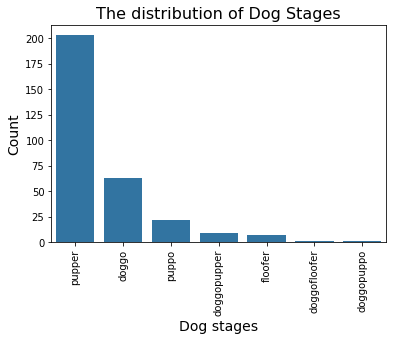

```python
# Code uses seaborn's '.countplot()' function to create a bar chart and uses a uniform color to plot all bars

base_color = sns.color_palette()[0]
sns.countplot(data=twitter_master, x='dog_stage', color=base_color, order=index_order);

# Code uses matplotlib's '.xticks()' function to rotate all x-labels

plt.xlabel('Dog stages', fontsize=14)
plt.ylabel('Count', fontsize=14)
plt.title('The distribution of Dog Stages', fontsize=16)
plt.xticks(rotation=90);
```

### Question 2: What is the success rate of the algorithms used for image predictions?

```python
# code outputs the total count of True and False values in the column

twitter_master['p1_dog'].value_counts()
```

```
True     1477
False     517
Name: p1_dog, dtype: int64
```

```python
# Code calculates the percent success rate by dividing the True counts by the total number of entries  and multiplying by 100

p1_success = 1477/1994 * 100
p1_success
```

```
74.07221664994985
```

```python
twitter_master['p2_dog'].value_counts()
```

```
True     1495
False     499
Name: p2_dog, dtype: int64
```

```python
p2_success = 1495/1994 * 100
p2_success
```

```
74.97492477432297
```

```python
twitter_master['p3_dog'].value_counts()
```

```
True     1446
False     548
Name: p3_dog, dtype: int64
```

```python
p3_success = 1446/1994 * 100
p3_success
```

```
72.51755265797392
```

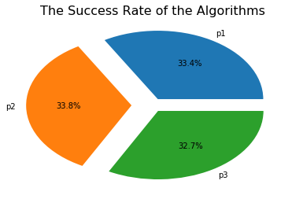

```python
# Code outputs a pie chart showing the success rate of the algorithm compared to the others.

plt.pie([p1_success, p2_success, p3_success], labels=('p1', 'p2', 'p3'), explode=[0.1, 0.2, 0.1], autopct='%1.1f%%')
plt.title('The Success Rate of the Algorithms', fontsize=16)
plt.show()
```

p2 is the most successful algorithm while p3 is the least successful algorithm